22 Nov 2026 · Albert

# The Hemisphere Cycle in Practice

Experience starts with the right hemisphere, passes through the left for clarity and structure, and returns to the right to be put back into a living whole.

- 1Presence right
- 2Representation left
- 3Return right

## The idea in short

Iain McGilchrist argues that the two brain hemispheres differ in how they attend to the world. Both take part in almost everything, including language and reasoning.

Right hemisphere

### Broad and open

The right hemisphere attends broadly and stays open to what is new. It takes a thing in as a whole, in its context.

Left hemisphere

### Narrow and focused

The left hemisphere attends narrowly and with focus. It grasps, names, separates and plans, which is what makes tools and maps possible.

He tells it through the story in the title of *The Master and His Emissary*. A wise master sends a trusted emissary to run his territory. The emissary is clever but sees less, comes to believe he is the master, and the territory suffers.

What matters for this doc is the order of work. Experience starts with the right hemisphere, passes through the left for clarity and structure, and returns to the right to be put back into a living whole. The sections below apply that loop to the cart example.

## Two ways of attending

The right hemisphere keeps the whole in view, and the left makes one piece of it workable.

| Aspect | Right hemisphere | Left hemisphere |
| --- | --- | --- |
| Attention | Broad, sustained, vigilant | Narrow and focused |
| Takes in | The whole, in its context | Parts and detail |
| New things | Registers new experience first | Works with what is fixed and familiar |
| World it presents | Interconnected, implicit, changing | Abstracted, compartmentalised, static |
| What it enables | Noticing what is actually there | Grasping, naming, reasoning, building tools |
| In the story | The Master | The Emissary |

In daily life both modes run together. McGilchrist's claim is about which one leads and which one serves. Table drawn from [Psychology Today](https://www.psychologytoday.com/us/blog/the-skeptical-brain/201012/attention-and-the-hemispheres), [BJGP](https://bjgp.org/content/66/642/44) and [Wikipedia](https://en.wikipedia.org/wiki/The_Master_and_His_Emissary).

## The healthy cycle

McGilchrist's healthy cycle runs from the right hemisphere to the left and back to the right.

[figure not shown]

Hemisphere cycle: 3 steps and a return.

Presence gives the first, whole picture. Representation makes it explicit and workable. The return checks the result against the whole, and the next pass begins there.

## The cart example, step by step

The cart demo went through the loop once, and the check at the end taught us something the tree had not.

1

### Presence

Right

The cycle begins with wording and a rough sketch, nothing more. The wording:

> When I click Add to cart on a product, the number next to the cart in the header goes up. The summary shows the same number. Clear sets it back to zero.

It is ambiguous on purpose. It does not say which components exist, or what Clear should do to the items.

[figure not shown]

Stage 1: wording and sketch, written for this doc.

2

### Representation

Left

The sketch became a tree: `App`, `CartProvider`, `Header`, `CartBadge`, `Main`, `ProductList`, `Product` and `CartSummary`. Each component got a role: provides, reads, writes, or passes through. `createContext` and `useContext` followed from that map. One provider owns `count`, and three kinds of consumer read it or change it.

[figure not shown]

Stage 2: the component tree. One provider feeds readers and writers in two branches.

3

### Return

Right

The page ran. Clicking Add to cart in a `Product` changed the badge in `Header`, which sits in a different branch, with no props passed between them. The render counters showed `Header`, `Main` and `ProductList` staying still.

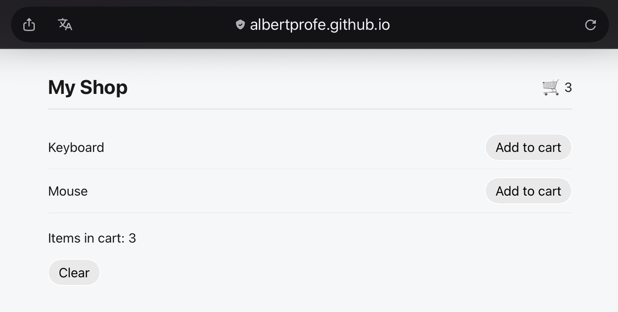

Stage 3: the running cart from the repo. The header badge and the summary both show 3.

The check in step 3 is made against the original picture, not against the code. It behaves like the sketch, so the idea survived. It also showed something the tree alone did not: every consumer re-renders when the count changes, even `Product`, which only calls `setCount`. That new detail is what feeds the next iteration.

## Where the emissary takes over

The loop breaks when the left-hemisphere step stops serving the picture and starts replacing it.

| Failure | What it looks like in the cart | The check that catches it |
| --- | --- | --- |
| Skipping step 1 | Starting from "use context" because it is the technique, then inventing components to fit it | Can you say in one sentence what the page should do when someone clicks? |
| Mistaking the map for the territory | A tree that looks right while nobody has clicked through the running page | Does the page behave like the original sketch? |
| Skipping step 3 | Giving the header and the summary their own `useState`. Each works alone, but the badge and the summary disagree | Click Add to cart and compare every place the count appears |
| The tool becomes the goal | Putting everything in context because it works, so every consumer re-renders on any change | Which components actually need this state? |
| The diagram becomes the work | Adding colours, toggles and legends to the tree while the page goes unopened | Is the diagram still answering a question the page raised? |

None of these is a mistake of skill. Each is what narrow, confident attention does when nothing brings it back to the whole.

## Using the cycle for the next iteration

The next iteration starts from a new ambiguous picture: a cart that holds real products with quantities and a total.

1 · Right

### Presence

Sketch one cart line: product name, quantity, price, and a way to remove it. Then a total under the list. Notice what is still unclear, such as what Clear should do to quantities.

2 · Left

### Representation

Replace the single number with an `items` array and a reducer with add, remove and clear actions. Predict the tree before touching it. We expect the same components, with only the shape of the context value changing.

3 · Right

### Return

Run it and compare with the sketch. If the tree held, the first picture was right. If a component had to move, the sketch was missing something, and that is worth knowing.

Each pass starts from a picture a little less ambiguous than the last.

## Caveats and sources

Treat this as a working method borrowed from a contested account, not as a claim about brain anatomy.

- McGilchrist's book came out in 2009 from Yale University Press, followed by *The Matter with Things* in 2021. Reviews were mixed.
- Critics, among them A. C. Grayling, Michael Corballis and Owen Flanagan, say the cultural conclusions go beyond what the neuroscience supports.
- Even in an overview written by McGilchrist, the evidence is called divided for some kinds of attention, and the two modes are described as not absolute.
- The three steps of presence, representation and return are his framing. The Wikipedia page describes the underlying idea as thought beginning in the right hemisphere, being processed for speech by the left, and having its meaning integrated again by the right.
- The loop is useful here only if it helps the work. That can be checked on every iteration, whatever the neuroscience says.

The pages I opened name the master and the emissary but do not retell the parable. Its wording in the first section is from my memory of the book's framing, so check it against the book.

### Sources

- [The Master and His Emissary, Wikipedia](https://en.wikipedia.org/wiki/The_Master_and_His_Emissary): publication details, the right-left-right idea, criticism.
- [Attention and the hemispheres, Psychology Today](https://www.psychologytoday.com/us/blog/the-skeptical-brain/201012/attention-and-the-hemispheres): attention types and evidence caveats.
- [BJGP article on McGilchrist's account](https://bjgp.org/content/66/642/44): broad and narrow attention, framed as a hypothesis.